# Predicting heart disease with classification trees

Sean Vucinich

April 23, 2017

```r
> library(rpart)
> library(rpart.plot)
> library(maptree)
Loading required package: cluster
> # the following utility files can be found attached to the assignment
> source("https://raw.githubusercontent.com/grbruns/cst383/master/lin-regr-util.R")
> source("https://raw.githubusercontent.com/grbruns/cst383/master/class-util.R")
```

### Reading and preprocessing the data

The first thing we do is we read in the data set and do some pre-processing upon the data.

```r
> heart = read.table("https://raw.githubusercontent.com/grbruns/cst383/master/heart.dat", quote = "/")
> names(heart) <- c("AGE", "SEX", "CHESTPAIN", "RESTBP", "CHOL",
+                   "SUGAR", "ECG", "MAXHR", "ANGINA", "DEP", "EXERCISE", "FLUOR",
+                   "THAL", "OUTPUT")
> names(heart) = tolower(names(heart))
>
> # convert output to factor
> heart$output = factor(heart$output)
```

### Data exploration

```r
>   #str(heart)
>   #summary(heart)
```

We should create some plots to observe some of the data for the sake of data exploration. In an attmept to observe something interesting in the data set, we’ll create a histogram of the ages(age) and a scatterplot of the cholesterol amounts versus the output condition of heart disease being present (chol and output).

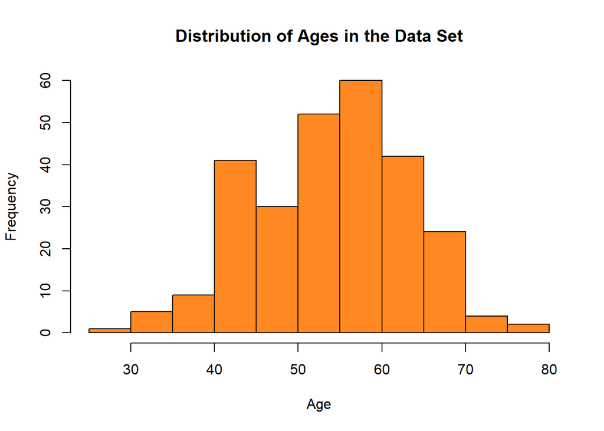

```r
> hist(heart$age, col = "#FF8822", main = "Distribution of Ages in the Data Set", xlab = "Age")
```

Looking at the histogram of the ages, we can observe that the majority of the ages in the population of the data set are between 40 and 70, with only a handful of the data points existing outside of that range.

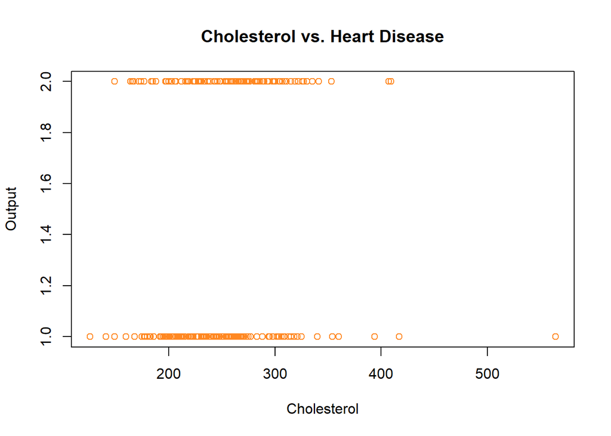

```r
> plot(heart$chol, heart$output, col = c("#FF8822"), main = "Cholesterol vs. Heart Disease", xlab = "Cholesterol", ylab = "Output")
```

Looking at this plot, we can see the distribution of heart disease being present in people with different Cholesterol amounts. For the y-axis, a y value of 1 is no heart disease and 2 is heart disease.

### Building a classification tree

Before we start building a classifcation tree, we need to split the data set up so we have data to train and test upon. The split_data function was defined in one of the source files (lin-regr-util.R), and we use a seed of 132 in order to allow for the results to be re-producible.

```r
> # training and test sets
> set.seed(132)
> split = split_data(heart)
> tr_dat = split[[1]]
> te_dat = split[[2]]
```

We will now build the first classification tree, using 3 features to create a tree that we can work to improve upon in the second model. These features will be chestpain, dep, and maxhr.

```r
> fit = rpart(output ~ chestpain + dep + maxhr,data=tr_dat, method="class")
```

```r
> #summary(fit)
```

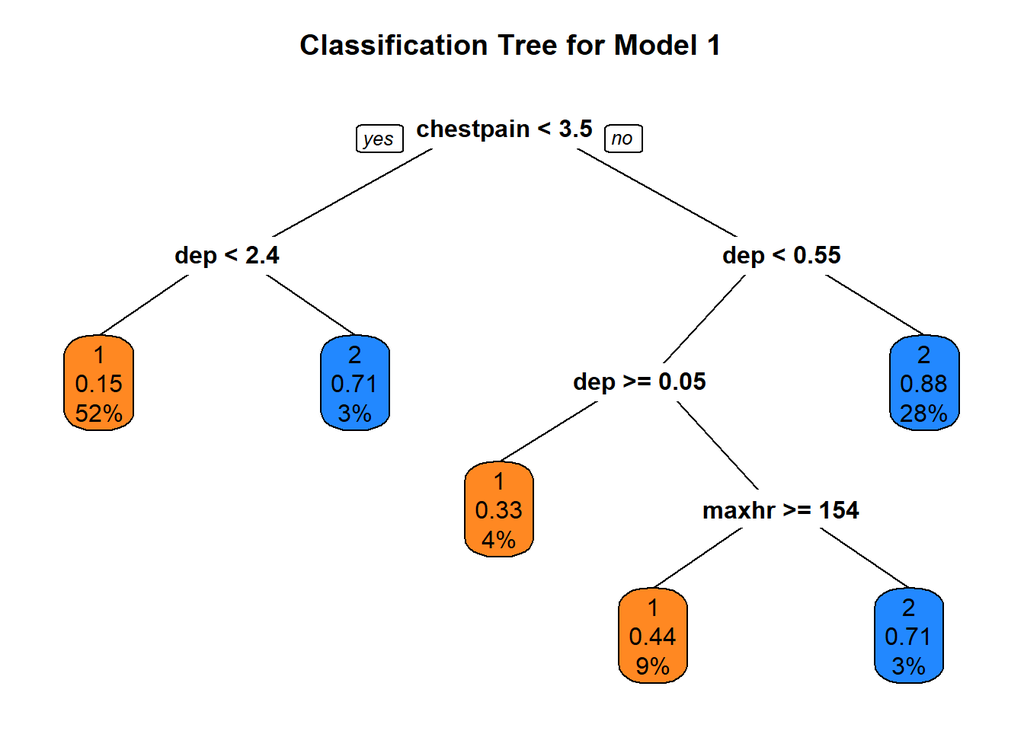

```r
> par(mar = c(1,1,3,1))
> prp(fit, extra=106, varlen=-10,main="Classification Tree for Model 1",box.col=c("#FF8822", "#2288FF")[fit$frame$yval])
```

From looking at the fitted tree and the summary, we can see that chestpain is a very significant feature in the prediction of the presence of heart disease. Dep and maxhr are also significant features, however are not as significant as chestpain is.

### Classifying test data

Now we run the model using the training and test data in order to generate predicitions. The training data was used in the creation of the model, and the test data is used now in the function predict in order to generate those predicitions.

```r
> predicted = predict(fit, te_dat, type="class")
> actual = te_dat$output
```

### Assessing the model

To begin assessing the effectiveness of the model, we will first calculating the accuracy of the model and also calculating the confusion matrix of the predictions.

```r
> success_rate = mean(predicted == actual)
> round(success_rate,3)
```

```
[1] 0.754
```

```r
> conf_matrix = table(actual, predicted)
> conf_matrix
```

```
      predicted
actual  1  2
     1 28  7
     2 10 24
```

The initial accuracy of the model is 75.4%, which is an ok accuracy for a first model but it can be improved upon. We can also calculate the false positive and false negative rates of the model in order to determine what bias, if any, the model has.

```r
> false_positive_rate = mean(predicted == 1 & actual == 2)
> round(false_positive_rate,3)
```

```
[1] 0.145
```

```r
> false_negative_rate = mean(predicted == 2 & actual == 1)
> round(false_negative_rate,3)
```

```
[1] 0.101
```

The false positive and negative rates of the model are both above 10% which is more then we would like. Now we will create a learning curve of the model to determine if the model has a high bias or a high varience.

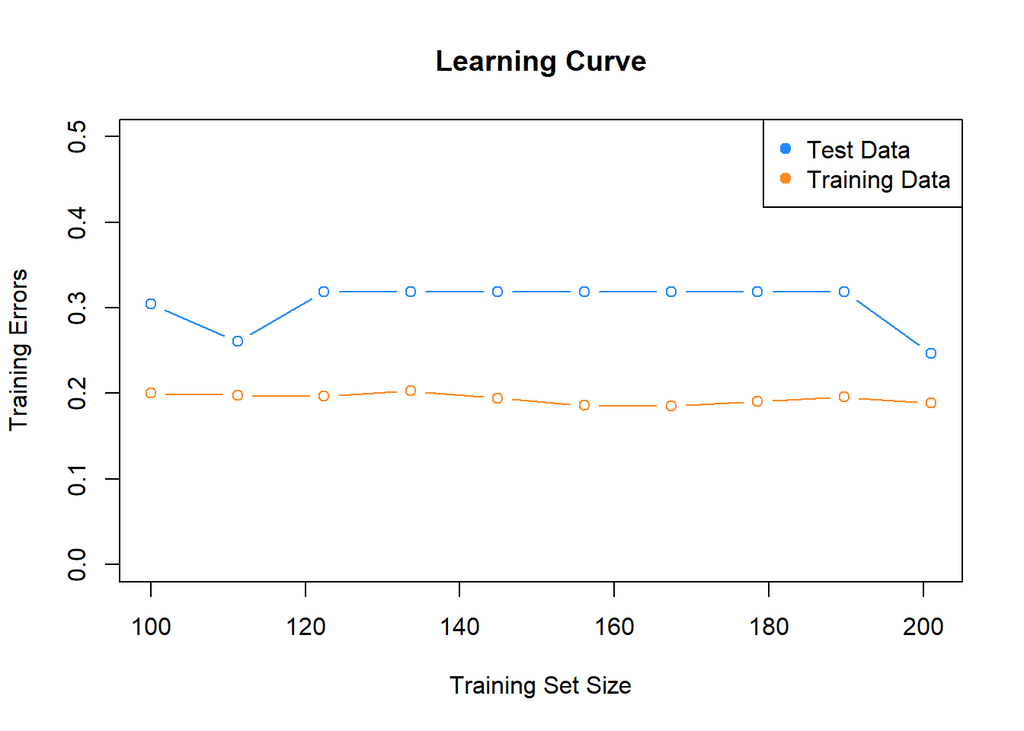

```r
> tr_errs = c()
> te_errs = c()
> te_actual = te_dat$output
> tr_sizes = seq(100, nrow(tr_dat), length.out=10)
> for (tr_size in tr_sizes)
+ {
+   tr_dat1 = tr_dat[1:tr_size,]
+   tr_actual = tr_dat1$output
+
+   fit1 = rpart(output ~ chestpain + dep + maxhr,data=tr_dat1, method="class")
+
+   # error on training set
+   tr_predicted = predict(fit1, tr_dat1, type="class")
+   err = mean(tr_actual != tr_predicted)
+   tr_errs = c(tr_errs, err)
+
+   # error on test set
+   te_predicted = predict(fit1, te_dat, type="class")
+   err = mean(te_actual != te_predicted)
+   te_errs = c(te_errs, err)
+ }
>
> plot(tr_sizes, tr_errs, col = "#FF8822", type = "b", ylim = c(0,0.5), main = "Learning Curve", xlab = "Training Set Size", ylab = "Training Errors")
> lines(tr_sizes, te_errs, col = "#2288FF", type = "b")
> legend("topright", legend = c("Test Data", "Training Data"), col = c("#2288FF", "#FF8822"), pch = 19)
```

Looking at the learning curve plot, it would appear this model is more prone to high bias.

### Model 2

```r
> fit2 = rpart(output ~ chestpain + thal + fluor, data = tr_dat, method = "class")
```

```r
> #summary(fit2)
```

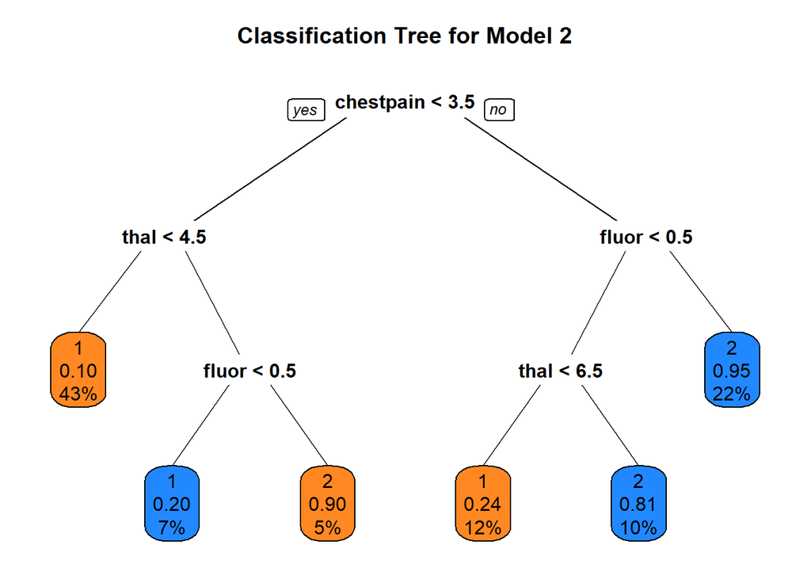

```r
> par(mar = c(1,1,3,1))
> prp(fit2, extra=106, varlen=-10,main="Classification Tree for Model 2",box.col=c("#FF8822", "#2288FF")[fit$frame$yval])
```

From looking at the fitted tree and the summary, we can see that chestpain is the most significant feature in the prediction of the presence of heart disease. This result corroborated by the fact that in the previous model, chestpain was also the most significant feature. Flour and thal are also significant features, with their significance being similar.

### Classifying test data

Now we run the model using the training and test data in order to generate predicitions. The training data was used in the creation of the model, and the test data is used now in the function predict in order to generate those predicitions.

```r
> predicted = predict(fit2, te_dat, type="class")
> actual = te_dat$output
```

### Assessing the model

To begin assessing the effectiveness of the model, we will first calculating the accuracy of the model and also calculating the confusion matrix of the predictions.

```r
> success_rate = mean(predicted == actual)
> round(success_rate,3)
```

```
[1] 0.826
```

```r
> conf_matrix = table(actual, predicted)
> conf_matrix
```

```
      predicted
actual  1  2
     1 28  7
     2  5 29
```

The initial accuracy of the model is 82.6%, which is significantly more accurate than the first model. We can also calculate the false positive and false negative rates of the model in order to determine what bias, if any, the model has.

```r
> false_positive_rate = mean(predicted == 1 & actual == 2)
> round(false_positive_rate,3)
```

```
[1] 0.072
```

```r
> false_negative_rate = mean(predicted == 2 & actual == 1)
> round(false_negative_rate,3)
```

```
[1] 0.101
```

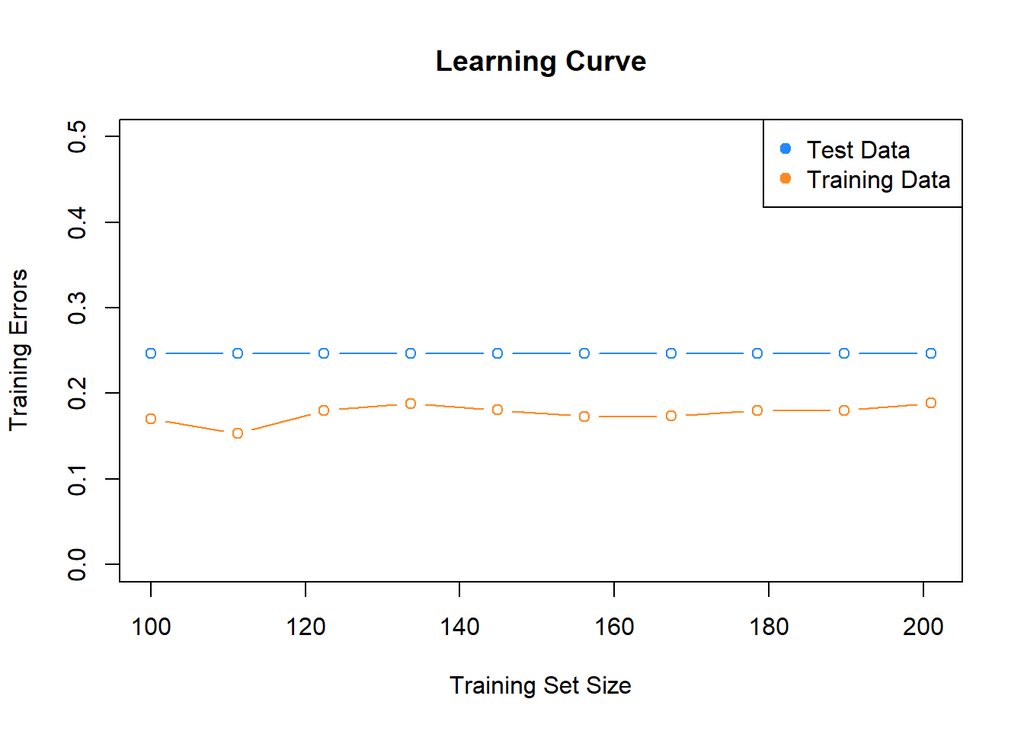

```r
> tr_errs = c()
> te_errs = c()
> te_actual = te_dat$output
> tr_sizes = seq(100, nrow(tr_dat), length.out=10)
> for (tr_size in tr_sizes)
+ {
+   tr_dat1 = tr_dat[1:tr_size,]
+   tr_actual = tr_dat1$output
+
+   fit2 = rpart(output ~ chestpain + thal + fluor, data = tr_dat1, method = "class")
+
+   # error on training set
+   tr_predicted = predict(fit1, tr_dat1, type="class")
+   err = mean(tr_actual != tr_predicted)
+   tr_errs = c(tr_errs, err)
+
+   # error on test set
+   te_predicted = predict(fit1, te_dat, type="class")
+   err = mean(te_actual != te_predicted)
+   te_errs = c(te_errs, err)
+ }
>
> plot(tr_sizes, tr_errs, col = "#FF8822", type = "b", ylim = c(0,0.5), main = "Learning Curve", xlab = "Training Set Size", ylab = "Training Errors")
> lines(tr_sizes, te_errs, col = "#2288FF", type = "b")
> legend("topright", legend = c("Test Data", "Training Data"), col = c("#2288FF", "#FF8822"), pch = 19)
```